# Data analysis: Marketing Campaign Impact on Term Deposit Subscriptions - A Comparative Analysis of Causal Inference Methods

2025-03-09

## Description of Problem

This project leverages a Marketing Dataset from a Portuguese banking institution to identify factors that influence a customer’s likelihood of subscribing to term deposits during a marketing campaign. Additionally, it evaluates the impact of direct calls on subscription rates. This project aims to compare the traditional ML causal inference methods, such as matching, with modern ML-based approaches like Double ML.

## Overview of data

The data is related with direct marketing campaigns of a Portuguese banking institution. The marketing campaigns were based on phone calls. Often, more than one contact to the same client was required, in order to access if the product (bank term deposit) would be (‘yes’) or not (‘no’) subscribed. The product in question (i.e., the bank term deposit) is a savings account that allows you to have interest in return for the unavailability of the money that’s put in for a certain period of time.

This dataset is based on “Bank Marketing” UCI dataset (link: http://archive.ics.uci.edu/ml/datasets/Bank+Marketing). Additionally, it is enriched with five new social and economic features/attributes (nation-wide indicators from a ~10M population country), published by the Banco de Portugal and publicly available at: https://www.bportugal.pt/estatisticasweb. The reason the authors enriched the dataset with these socio-economic variables is because they found the addition lead to substantial improvement in the prediction of a success, even when the duration of the call is not included.

The data is ordered by date (from May 2008 to November 2010). Additionally, for testing the performance of computationally intensive models, the file bank-additional.csv with 10% of the examples (4119), randomly selected from bank-additional-full.csv is provided.

Additionally, we know from the outset that this database is trimmed for all the attempted outbound calls made which did not get answered i.e., all the people that were contacted unexpectedly who did not pick up over the course of the entire marketing campaign. Furthermore, we know from the paper that there were two types of calls - outbound and inbound calls - where the former is the situation where the bank does pure cold-calling and covers the entire database of potential contacts without selection (i.e., hence why the paper was exploring whether to do a predictive algorithm to improve efficiency of the cold-calling process through better targeting) and the latter which is the situation where an individual calls the bank for another reason and is also marketed this product.

## Variables for bank additional dataset

This is supposedly the cleaner dataset but has some variables omitted from the original bank dataset and the addition of the MACRO variables (which was explained in the paper to have signicantly improved the predictive performance of the ML algorithms).

### Variables related to bank client data:

- age (numeric)
- job : type of job (categorical: “admin.”,“blue-collar”,“entrepreneur”,“housemaid”,“management”,“retired”,“self-employed”,“services”,“student”,“technician”,“unemployed”,“unknown”)
- marital : marital status (categorical: “divorced”,“married”,“single”,“unknown”; note: “divorced” means divorced or widowed) *education (categorical: “basic.4y”,“basic.6y”,“basic.9y”,“high.school”,“illiterate”,“professional.course”,“university.degree”,“unknown”)
- default: has credit in default? (categorical: “no”,“yes”,“unknown”)
- housing: has housing loan? (categorical: “no”,“yes”,“unknown”)
- loan: has personal loan? (categorical: “no”,“yes”,“unknown”)

### Variables related to the previous attempts at being contacted:

- contact: contact communication type (categorical: “cellular”,“telephone”)
- month: last contact month of year (categorical: “jan”, “feb”, “mar”, …, “nov”, “dec”)
- day_of_week: last contact day of the week (categorical: “mon”,“tue”,“wed”,“thu”,“fri”)
- duration: last contact duration, in seconds (numeric). Important note: this attribute highly affects the output target (e.g., if duration=0 then y=“no”). Yet, the duration is not known before a call is performed. Also, after the end of the call y is obviously known. Thus, this input should only be included for benchmark purposes and should be discarded if the intention is to have a realistic predictive model.
- campaign: number of contacts performed during this campaign and for this client (numeric, includes last contact)
- pdays: number of days that passed by after the client was last contacted from a previous campaign (numeric; 999 means client was not previously contacted)
- previous: number of contacts performed before this campaign and for this client (numeric)
- poutcome: outcome of the previous marketing campaign (categorical: “failure”,“nonexistent”,“success”)

### Variables related to the state of the economy

- emp.var.rate: employment variation rate - quarterly indicator (numeric)
- cons.price.idx: consumer price index - monthly indicator (numeric)
- cons.conf.idx: consumer confidence index - monthly indicator (numeric)
- euribor3m: euribor 3 month rate - daily indicator (numeric)
- nr.employed: number of employees - quarterly indicator (numeric)

### Outcome variable:

- y - has the client subscribed a term deposit? (binary: “yes”,“no”)

## Missing values (for both datasets):

There are several missing values in several variables, all coded with the “unknown” label.

## Variables for bank dataset

This dataset does not contain any macro-related variables as well as the day of the week variable (i.e., on what day of the working week did the call take place). However, it does include the following variables which are not included in the final clean dataset (i.e., bank additional full):

- balance - average yearly balance, in euros (numeric)
- day: last contact day of the month (numeric)

## PICO formulation:

- Population : Who are we interested in? - Portuguese potential customers being contacted or contacting the bank
- Intervention : What treatment/intervention do we study? - Marketing campaign aspects (*Note: there are different aspects we will explore*)
1. the call taking place in the middle of the working week (“business mindset”) vs the rest of the week (“leisure or work catchup” mindset)
2. the call taking place at the end of the month vs the rest of the month or the beginning of the month vs the rest of the month (i.e., because people tend to have higher account balances at the beginning of the month relative to the end)
- Control : What are we comparing it to/who is our control group: Population with different characteristics e.g., different economic context, different job, different number of calls prior to current call etc.
- Outcome : What are we interested in? - Likelihood of subscribing to the term deposit product
- Time : Outcome is determined after call ends (i.e., directly after treatment)

```r
# Packages:
library(data.table)
library(dplyr)
```

```r
library(corrplot) # for correlation plot
library(GGally) # for plotting
library(DiagrammeR) # for DAG
library(DoubleML) # for double debiased ML
library(mlr3)
#install.packages("arrow")
library(arrow) # for opening up .feather files
# Install packages if they are not already installed
# install.packages(c("mice", "ggplot2", "naniar"))

# Load the packages
library(mice)
library(ggplot2)
library(naniar)
```

```r
# Packages:
# data <- read.csv("bank-additional-full.csv", sep = ";")
data_table <- fread("data/marketing/bank-additional-full.csv", sep = ";")
data_table_unclean <- fread("data/marketing/bank-full.csv", sep = ";")

# classifying variables other than the outcome
categorical_variable_names  <- c("job", "marital", "education", "default", "housing",
                                 "housing", "loan", "contact", "month", "day_of_week",
                                 "poutcome")
numerical_variable_names <- c("age", "duration", "campaign", "pdays", "previous",
                              "cons.price.idx", "cons.conf.idx", "euribor3m", "nr.employed",
                              "emp.var.rate")

summary(data_table)
```

```
##       age            job              marital           education
##  Min.   :17.00   Length:41188       Length:41188       Length:41188
##  1st Qu.:32.00   Class :character   Class :character   Class :character
##  Median :38.00   Mode  :character   Mode  :character   Mode  :character
##  Mean   :40.02
##  3rd Qu.:47.00
##  Max.   :98.00
##    default            housing              loan             contact
##  Length:41188       Length:41188       Length:41188       Length:41188
##  Class :character   Class :character   Class :character   Class :character
##  Mode  :character   Mode  :character   Mode  :character   Mode  :character
##
##
##
##     month           day_of_week           duration         campaign
##  Length:41188       Length:41188       Min.   :   0.0   Min.   : 1.000
##  Class :character   Class :character   1st Qu.: 102.0   1st Qu.: 1.000
##  Mode  :character   Mode  :character   Median : 180.0   Median : 2.000
##                                        Mean   : 258.3   Mean   : 2.568
##                                        3rd Qu.: 319.0   3rd Qu.: 3.000
##                                        Max.   :4918.0   Max.   :56.000
##      pdays          previous       poutcome          emp.var.rate
##  Min.   :  0.0   Min.   :0.000   Length:41188       Min.   :-3.40000
##  1st Qu.:999.0   1st Qu.:0.000   Class :character   1st Qu.:-1.80000
##  Median :999.0   Median :0.000   Mode  :character   Median : 1.10000
##  Mean   :962.5   Mean   :0.173                      Mean   : 0.08189
##  3rd Qu.:999.0   3rd Qu.:0.000                      3rd Qu.: 1.40000
##  Max.   :999.0   Max.   :7.000                      Max.   : 1.40000
##  cons.price.idx  cons.conf.idx     euribor3m      nr.employed
##  Min.   :92.20   Min.   :-50.8   Min.   :0.634   Min.   :4964
##  1st Qu.:93.08   1st Qu.:-42.7   1st Qu.:1.344   1st Qu.:5099
##  Median :93.75   Median :-41.8   Median :4.857   Median :5191
##  Mean   :93.58   Mean   :-40.5   Mean   :3.621   Mean   :5167
##  3rd Qu.:93.99   3rd Qu.:-36.4   3rd Qu.:4.961   3rd Qu.:5228
##  Max.   :94.77   Max.   :-26.9   Max.   :5.045   Max.   :5228
##       y
##  Length:41188
##  Class :character
##  Mode  :character
##
##
##
```

```r
head(data_table)
```

```
##      age       job marital   education default housing   loan   contact  month
##    <int>    <char>  <char>      <char>  <char>  <char> <char>    <char> <char>
## 1:    56 housemaid married    basic.4y      no      no     no telephone    may
## 2:    57  services married high.school unknown      no     no telephone    may
## 3:    37  services married high.school      no     yes     no telephone    may
## 4:    40    admin. married    basic.6y      no      no     no telephone    may
## 5:    56  services married high.school      no      no    yes telephone    may
## 6:    45  services married    basic.9y unknown      no     no telephone    may
##    day_of_week duration campaign pdays previous    poutcome emp.var.rate
##         <char>    <int>    <int> <int>    <int>      <char>        <num>
## 1:         mon      261        1   999        0 nonexistent          1.1
## 2:         mon      149        1   999        0 nonexistent          1.1
## 3:         mon      226        1   999        0 nonexistent          1.1
## 4:         mon      151        1   999        0 nonexistent          1.1
## 5:         mon      307        1   999        0 nonexistent          1.1
## 6:         mon      198        1   999        0 nonexistent          1.1
##    cons.price.idx cons.conf.idx euribor3m nr.employed      y
##             <num>         <num>     <num>       <num> <char>
## 1:         93.994         -36.4     4.857        5191     no
## 2:         93.994         -36.4     4.857        5191     no
## 3:         93.994         -36.4     4.857        5191     no
## 4:         93.994         -36.4     4.857        5191     no
## 5:         93.994         -36.4     4.857        5191     no
## 6:         93.994         -36.4     4.857        5191     no
```

## Outcome variable:

```r
# looking at the outcome
print("outcome - y")
```

```
## [1] "outcome - y"
```

```r
table(data_table$y) # imbalanced in favour of "no", this imbalance further makes sense
```

```
##
##    no   yes
## 36548  4640
```

```r
#               when considering each row is an attempt and not an individual
```

Looking at the outcome, there is an imbalance in favour of “no”, which makes sense independently of the structure of the dataset given we would expect that most people contacted would not subscribe to the product. Considering the structure of the dataset, this imbalance makes further sense when considering each row is an attempt and not an individual, so even if an individual eventually agrees to subscribe, we would consider all the previous unsuccessful attempts.

## Categorical variables:

```r
# looking at categorical variables
print("job")
```

```
## [1] "job"
```

```r
table(data_table$job)
```

```
##
##        admin.   blue-collar  entrepreneur     housemaid    management
##         10422          9254          1456          1060          2924
##       retired self-employed      services       student    technician
##          1720          1421          3969           875          6743
##    unemployed       unknown
##          1014           330
```

```r
print("marital status")
```

```
## [1] "marital status"
```

```r
table(data_table$marital)
```

```
##
## divorced  married   single  unknown
##     4612    24928    11568       80
```

```r
print("level of education")
```

```
## [1] "level of education"
```

```r
table(data_table$education)
```

```
##
##            basic.4y            basic.6y            basic.9y         high.school
##                4176                2292                6045                9515
##          illiterate professional.course   university.degree             unknown
##                  18                5243               12168                1731
```

```r
print("currently has credit in default?")
```

```
## [1] "currently has credit in default?"
```

```r
table(data_table$default) # Variable: currently has credit in default
```

```
##
##      no unknown     yes
##   32588    8597       3
```

```r
print("currently has a housing loan?")
```

```
## [1] "currently has a housing loan?"
```

```r
table(data_table$housing) # Variable: currently has a housing loan
```

```
##
##      no unknown     yes
##   18622     990   21576
```

```r
print("currently has a personal loan?")
```

```
## [1] "currently has a personal loan?"
```

```r
table(data_table$loan)
```

```
##
##      no unknown     yes
##   33950     990    6248
```

```r
print("medium of contact")
```

```
## [1] "medium of contact"
```

```r
table(data_table$contact)
```

```
##
##  cellular telephone
##     26144     15044
```

```r
print("month contacted")
```

```
## [1] "month contacted"
```

```r
table(data_table$month) # By far most contacts done in May, and very few in December
```

```
##
##   apr   aug   dec   jul   jun   mar   may   nov   oct   sep
##  2632  6178   182  7174  5318   546 13769  4101   718   570
```

```r
print("day of the week contacted")
```

```
## [1] "day of the week contacted"
```

```r
table(data_table$day_of_week) # equally split between work days of the week
```

```
##
##  fri  mon  thu  tue  wed
## 7827 8514 8623 8090 8134
```

```r
print("outcome of last marketing campaign")
```

```
## [1] "outcome of last marketing campaign"
```

```r
table(data_table$poutcome) # Variable: previous outcome of the last marketing campaign - most potential customers haven't been involved in previous campaigns (see previous)
```

```
##
##     failure nonexistent     success
##        4252       35563        1373
```

Looking at the categorical variables, a striking feature is that the successful contacts are spread out equally between the work days of the week, which is likely a supply-side feature more than a demand-side one (i.e., it is more likely that the firm’s employees work equally throughout the week. Another interesting feature is that by far, most successful contacts were carried out in May, which may be a demand-side pressure (i.e., are customers more likely to answer shortly before the summer period to anticipate large spends during the summer?), and then there are very few contacts carried out in December, likely due to the holidays. Additionally, using the poutcome variable, we can see that most of the potential customers successfully contacted are those who have not been involved in previous campaigns, which makes sense, as they are likely to have more success with contacts with customers who have not been contacted before than those who have and have declined to subscribe.

## Numerical variables:

```r
# looking at numerical variables
print("age")
```

```
## [1] "age"
```

```r
summary(data_table$age) # 17-98 years old potential customers
```

```
##    Min. 1st Qu.  Median    Mean 3rd Qu.    Max.
##   17.00   32.00   38.00   40.02   47.00   98.00
```

```r
print("contact duration in seconds")
```

```
## [1] "contact duration in seconds"
```

```r
summary(data_table$duration) # last contact duration in seconds 102-4918 seconds, on average 258 seconds (~4 mins)
```

```
##    Min. 1st Qu.  Median    Mean 3rd Qu.    Max.
##     0.0   102.0   180.0   258.3   319.0  4918.0
```

```r
print("number of previous contacts in current campaign")
```

```
## [1] "number of previous contacts in current campaign"
```

```r
summary(data_table$campaign) # number of previous contacts in CURRENT CAMPAIGN, 1-56 times, on average contacted 2.6 times
```

```
##    Min. 1st Qu.  Median    Mean 3rd Qu.    Max.
##   1.000   1.000   2.000   2.568   3.000  56.000
```

```r
print("number of days passed since last contact")
```

```
## [1] "number of days passed since last contact"
```

```r
summary(data_table$pdays) # number of days since last contact, 0-999 days, on average contacted 962.5 days
```

```
##    Min. 1st Qu.  Median    Mean 3rd Qu.    Max.
##     0.0   999.0   999.0   962.5   999.0   999.0
```

```r
# mode (top 3 most frequent) - 999 is by far most frequent
print("3 most frequent values of this variable")
```

```
## [1] "3 most frequent values of this variable"
```

```r
names(sort(-table(data_table$pdays)))[1:3]
```

```
## [1] "999" "3"   "6"
```

```r
print("number of previous contacts in previous campaign")
```

```
## [1] "number of previous contacts in previous campaign"
```

```r
summary(data_table$previous) # number of previous contacts in PREVIOUS CAMPAIGN, 0-7 times, on average contacted 0.173 times
```

```
##    Min. 1st Qu.  Median    Mean 3rd Qu.    Max.
##   0.000   0.000   0.000   0.173   0.000   7.000
```

```r
print("consumer price index")
```

```
## [1] "consumer price index"
```

```r
summary(data_table$cons.price.idx) #
```

```
##    Min. 1st Qu.  Median    Mean 3rd Qu.    Max.
##   92.20   93.08   93.75   93.58   93.99   94.77
```

```r
print("consumer confidence index")
```

```
## [1] "consumer confidence index"
```

```r
summary(data_table$cons.conf.idx) #
```

```
##    Min. 1st Qu.  Median    Mean 3rd Qu.    Max.
##   -50.8   -42.7   -41.8   -40.5   -36.4   -26.9
```

```r
print("Euribor 3m")
```

```
## [1] "Euribor 3m"
```

```r
summary(data_table$euribor3m) #
```

```
##    Min. 1st Qu.  Median    Mean 3rd Qu.    Max.
##   0.634   1.344   4.857   3.621   4.961   5.045
```

```r
print("Number of employed quarterly")
```

```
## [1] "Number of employed quarterly"
```

```r
summary(data_table$nr.employed) #
```

```
##    Min. 1st Qu.  Median    Mean 3rd Qu.    Max.
##    4964    5099    5191    5167    5228    5228
```

```r
print("Employment variation rate")
```

```
## [1] "Employment variation rate"
```

```r
summary(data_table$emp.var.rate)
```

```
##     Min.  1st Qu.   Median     Mean  3rd Qu.     Max.
## -3.40000 -1.80000  1.10000  0.08189  1.40000  1.40000
```

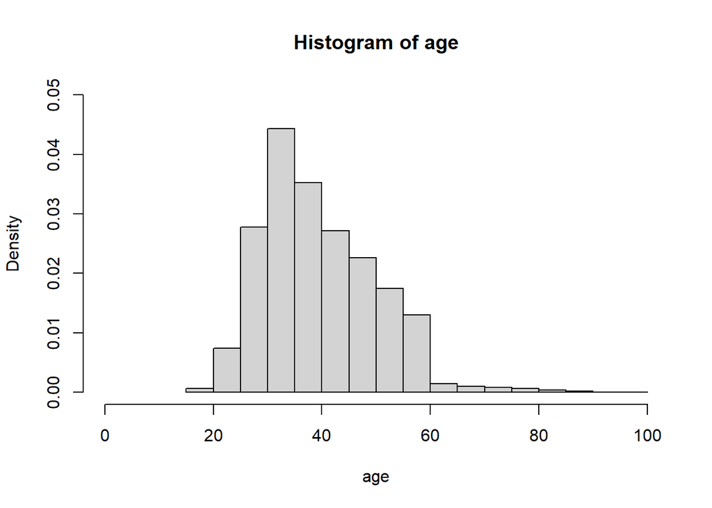

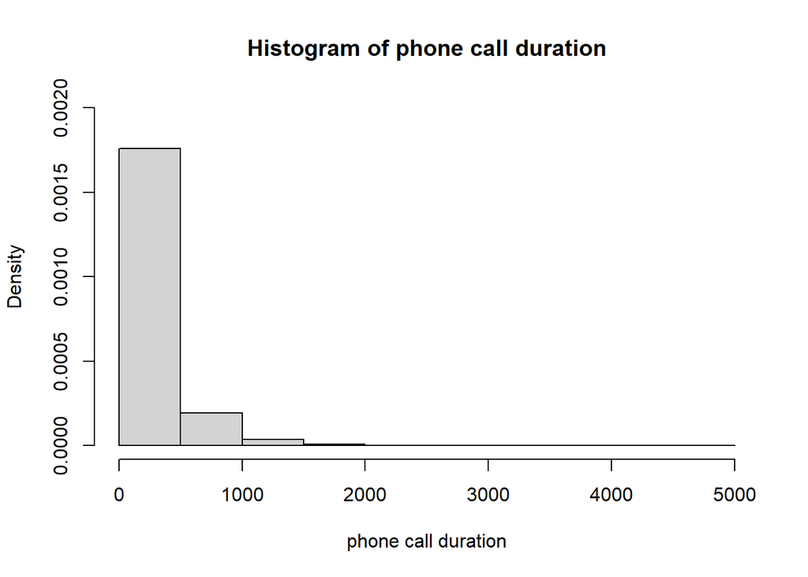

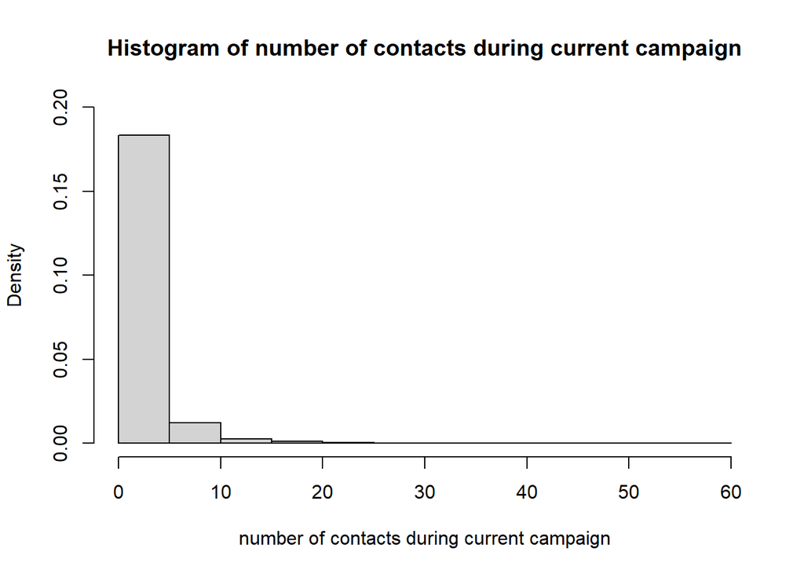

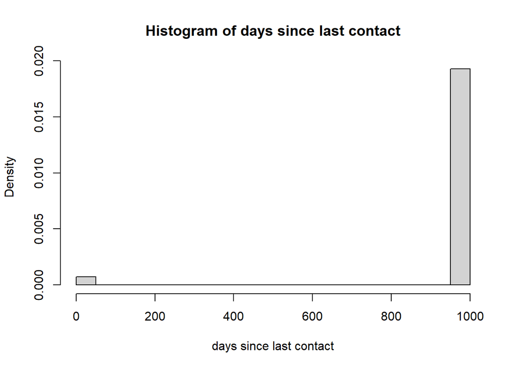

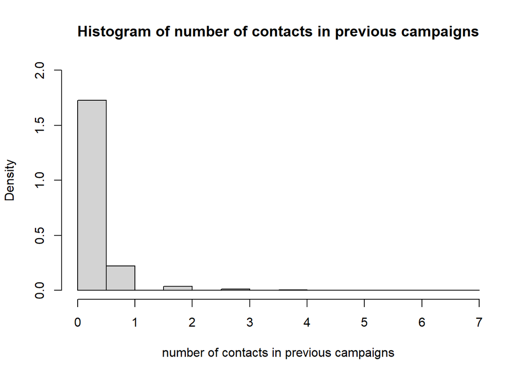

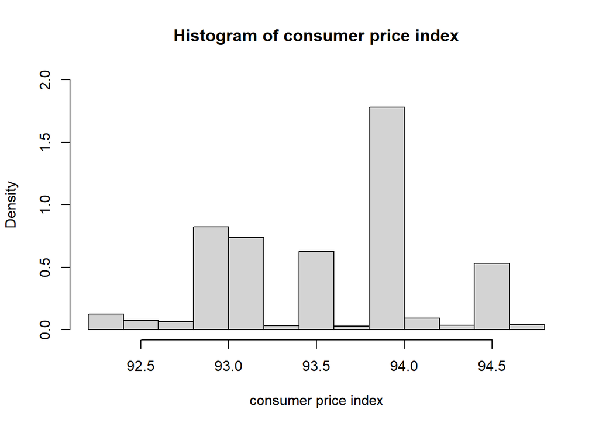

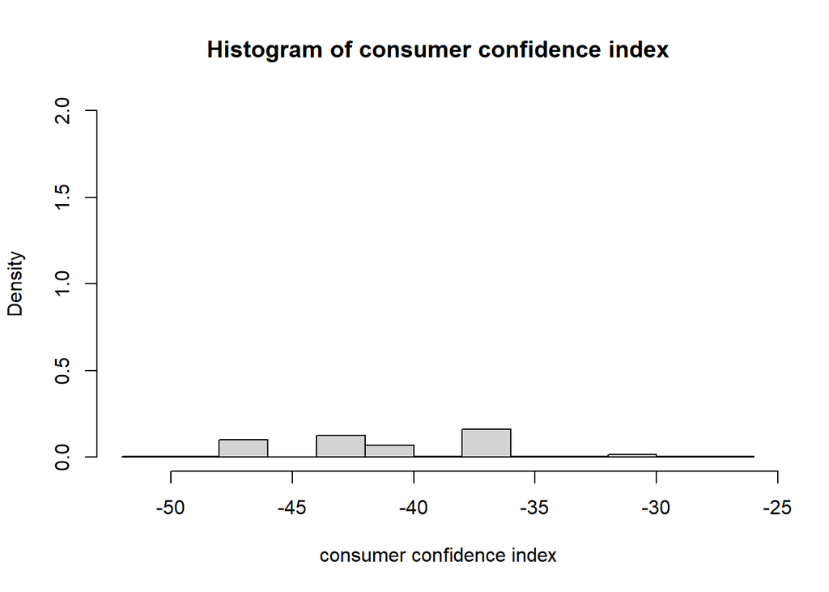

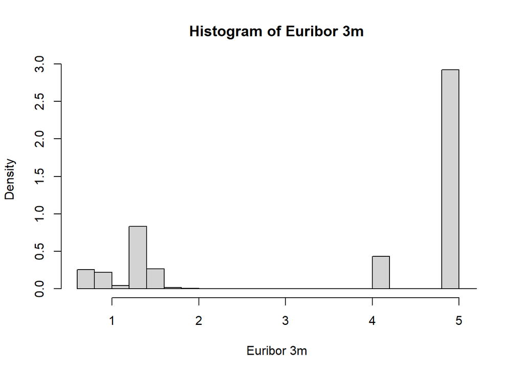

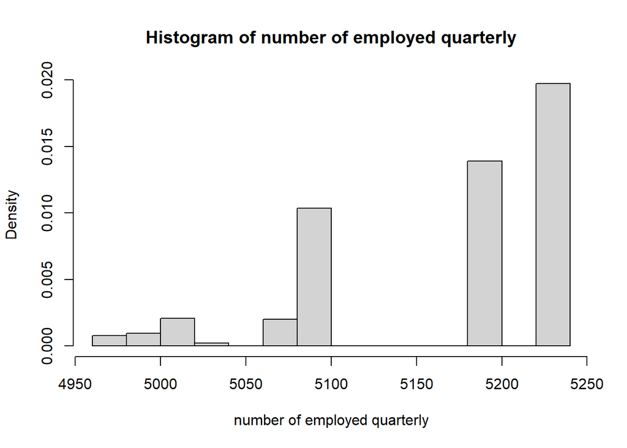

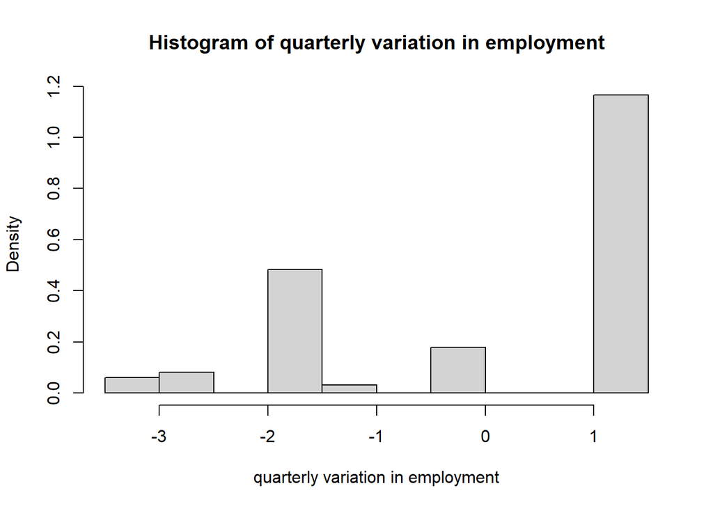

Additionally, we can see that on average, for those who pick up people spend around 4 mins on the marketing call.

So overall, it seems that customers tend to be successfully contacted when future expectations of the future economy are low, and so may want to plan ahead financially and consequently, be more open to getting the product proposed.

## Simple success rate over campaign factors

```
## # A tibble: 5 × 2
##   day_of_week success
##   <chr>         <dbl>
## 1 fri          0.108
## 2 mon          0.0995
## 3 thu          0.121
## 4 tue          0.118
## 5 wed          0.117
```

```
## # A tibble: 10 × 2
##    month success
##    <chr>   <dbl>
##  1 apr    0.205
##  2 aug    0.106
##  3 dec    0.489
##  4 jul    0.0905
##  5 jun    0.105
##  6 mar    0.505
##  7 may    0.0643
##  8 nov    0.101
##  9 oct    0.439
## 10 sep    0.449
```

There seems to be a lot of variation between months but this could be due to the bulk of the data being from pre-2008 financial crisis and so this may be more the MACRO aspect of moment relative to the crisis more than general seasonality.

## Correlation plot of numerical variables

```
##                          age     duration    campaign       pdays    previous
## age             1.0000000000 -0.000865705  0.00459358 -0.03436895  0.02436474
## duration       -0.0008657050  1.000000000 -0.07169923 -0.04757702  0.02064035
## campaign        0.0045935805 -0.071699226  1.00000000  0.05258357 -0.07914147
## pdays          -0.0343689512 -0.047577015  0.05258357  1.00000000 -0.58751386
## previous        0.0243647409  0.020640351 -0.07914147 -0.58751386  1.00000000
## cons.price.idx  0.0008567150  0.005312268  0.12783591  0.07888911 -0.20312997
## cons.conf.idx   0.1293716142 -0.008172873 -0.01373310 -0.09134235 -0.05093635
## euribor3m       0.0107674295 -0.032896656  0.13513251  0.29689911 -0.45449365
## nr.employed    -0.0177251319 -0.044703223  0.14409489  0.37260474 -0.50133293
## emp.var.rate   -0.0003706855 -0.027967884  0.15075381  0.27100417 -0.42048911
##                cons.price.idx cons.conf.idx   euribor3m nr.employed
## age               0.000856715   0.129371614  0.01076743 -0.01772513
## duration          0.005312268  -0.008172873 -0.03289666 -0.04470322
## campaign          0.127835912  -0.013733099  0.13513251  0.14409489
## pdays             0.078889109  -0.091342354  0.29689911  0.37260474
## previous         -0.203129967  -0.050936351 -0.45449365 -0.50133293
## cons.price.idx    1.000000000   0.058986182  0.68823011  0.52203398
## cons.conf.idx     0.058986182   1.000000000  0.27768622  0.10051343
## euribor3m         0.688230107   0.277686220  1.00000000  0.94515443
## nr.employed       0.522033977   0.100513432  0.94515443  1.00000000
## emp.var.rate      0.775334171   0.196041268  0.97224467  0.90697010
##                 emp.var.rate
## age            -0.0003706855
## duration       -0.0279678845
## campaign        0.1507538056
## pdays           0.2710041743
## previous       -0.4204891094
## cons.price.idx  0.7753341708
## cons.conf.idx   0.1960412681
## euribor3m       0.9722446712
## nr.employed     0.9069701013
## emp.var.rate    1.0000000000
```

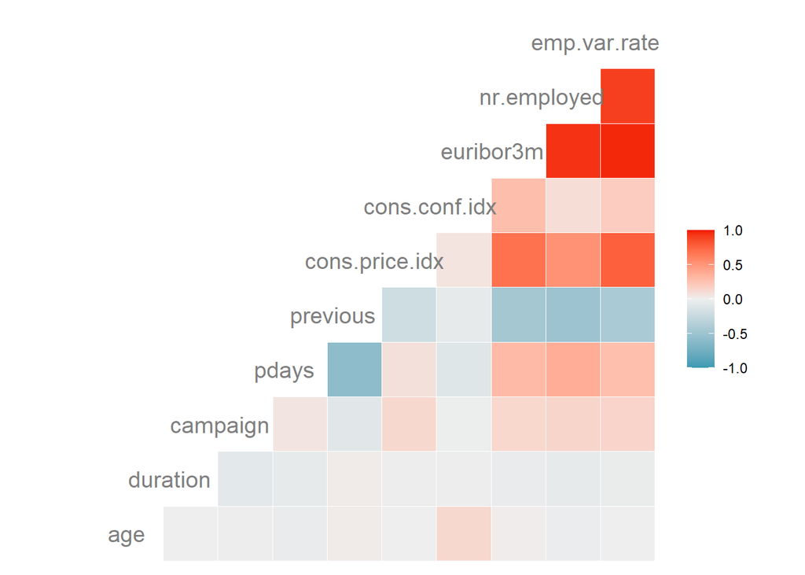

Here, we will mostly explore the relationship between the marketing campaign variables and other variables (i.e., not focusing on the relationship between MACRO variables) where there are not very strong correlations. For example, we see that previous and pdays are negatively correlated. As a reminder, previous is the number of contacts performed in the last campaign and pdays is the number of days since the last contact. It makes sense that the more contacts there have been, the fewer the days there tends to be since the last contact.

After data exploration, we have seen that in the original dataset (i.e., bank full), we have a strong suspicion of duplicate values, as seen as rows of very unlikely combinations with a different number of campaign values (i.e., total number of succesful contacts) which suggests there were several rows that correspond to the same individual over time. However, we assume this is minor and as the final dataset (i.e., bank additional full) is corrected and cleaned, we assume this to be not an issue at all in this dataset.

Additionally, we can explore data imputation techniques to deal with “unknown” values in all variables.

## Selection of Methods

Double (post) lasso doesn’t make much sense given we have a very long panel data here.

We will be doing: * Matching * Double Debiased ML

## Variables of interest for the first problem (i.e., Day of the Week)

Recalling the variables that will be used in the construction of the Heterogeneity variable (Z): * day_of_week: last contact day of the week (categorical: “mon”,“tue”,“wed”,“thu”,“fri”)

## Process of cleaning databases

Here below, I am using a cleaned and reformatted databases and filtering for successful contacts where it was the only contact of the campaign, as in the paper it mentioned that most of the following contacts were at the request of the customer, and therefore, not realistically a lever of the campaign the bank can control.

```r
# Clearing environment from old variables
rm(data_table)
rm(data_table_month)
rm(data_table_day_of_week)
rm(cor_matrix)
rm(data_table_unclean)
rm(numeric_data)
rm(numeric_data_wo_na)

# Read the .feather file
data_table_bank <- as.data.table(arrow::read_feather("results_building/bank-full.feather"))
data_table_bank_additional <- as.data.table(arrow::read_feather("results_building/bank-additional-full.feather"))

dt_bank_filtered <- data_table_bank %>%
  filter(campaign == 1)

dt_bank_additional_filtered <- data_table_bank_additional %>%
  filter(campaign == 1)

print(summary(dt_bank_filtered))
```

```
##       y                  age          date_month              day
##  Length:17544       Min.   :18.00   Min.   :2008-05-01   Min.   : 1.00
##  Class :character   1st Qu.:32.00   1st Qu.:2008-06-01   1st Qu.: 7.00
##  Mode  :character   Median :38.00   Median :2008-11-01   Median :15.00
##                     Mean   :40.66   Mean   :2008-12-24   Mean   :14.75
##                     3rd Qu.:48.00   3rd Qu.:2009-05-01   3rd Qu.:20.00
##                     Max.   :95.00   Max.   :2010-11-01   Max.   :31.00
##      job              marital           education           default
##  Length:17544       Length:17544       Length:17544       Length:17544
##  Class :character   Class :character   Class :character   Class :character
##  Mode  :character   Mode  :character   Mode  :character   Mode  :character
##
##
##
##     balance         housing              loan             contact
##  Min.   : -6847   Length:17544       Length:17544       Length:17544
##  1st Qu.:    84   Class :character   Class :character   Class :character
##  Median :   477   Mode  :character   Mode  :character   Mode  :character
##  Mean   :  1415
##  3rd Qu.:  1495
##  Max.   :102127
##     duration         campaign     pdays           previous
##  Min.   :   1.0   Min.   :1   Min.   : -1.00   Min.   : 0.0000
##  1st Qu.: 111.0   1st Qu.:1   1st Qu.: -1.00   1st Qu.: 0.0000
##  Median : 190.0   Median :1   Median : -1.00   Median : 0.0000
##  Mean   : 261.1   Mean   :1   Mean   : 49.48   Mean   : 0.6164
##  3rd Qu.: 323.0   3rd Qu.:1   3rd Qu.: -1.00   3rd Qu.: 0.0000
##  Max.   :4918.0   Max.   :1   Max.   :871.00   Max.   :41.0000
##    poutcome          euribor_12mo        hicp        cons_confidence
##  Length:17544       Min.   :1.215   Min.   :-1.800   Min.   :-40.10
##  Class :character   1st Qu.:1.771   1st Qu.:-0.500   1st Qu.:-30.30
##  Mode  :character   Median :4.820   Median : 2.500   Median :-27.00
##                     Mean   :3.530   Mean   : 1.303   Mean   :-26.73
##                     3rd Qu.:4.994   3rd Qu.: 2.500   3rd Qu.:-23.40
##                     Max.   :5.393   Max.   : 3.400   Max.   :-10.30
##   unemployment     stoxx_return
##  Min.   : 7.600   Min.   :-13.2700
##  1st Qu.: 7.700   1st Qu.: -7.1200
##  Median : 7.900   Median : -0.3000
##  Mean   : 8.691   Mean   : -0.7675
##  3rd Qu.: 9.400   3rd Qu.:  3.9900
##  Max.   :11.400   Max.   : 13.4700
```

```r
print(head(dt_bank_filtered))
```

```
##         y   age date_month   day          job marital education default balance
##    <char> <int>     <Date> <int>       <char>  <char>    <char>  <char>   <int>
## 1:     no    58 2008-05-01     5   management married  tertiary      no    2143
## 2:     no    44 2008-05-01     5   technician  single secondary      no      29
## 3:     no    33 2008-05-01     5 entrepreneur married secondary      no       2
## 4:     no    47 2008-05-01     5  blue-collar married   unknown      no    1506
## 5:     no    33 2008-05-01     5      unknown  single   unknown      no       1
## 6:     no    35 2008-05-01     5   management married  tertiary      no     231
##    housing   loan contact duration campaign pdays previous poutcome
##     <char> <char>  <char>    <int>    <int> <int>    <int>   <char>
## 1:     yes     no unknown      261        1    -1        0  unknown
## 2:     yes     no unknown      151        1    -1        0  unknown
## 3:     yes    yes unknown       76        1    -1        0  unknown
## 4:     yes     no unknown       92        1    -1        0  unknown
## 5:      no     no unknown      198        1    -1        0  unknown
## 6:     yes     no unknown      139        1    -1        0  unknown
##    euribor_12mo  hicp cons_confidence unemployment stoxx_return
##           <num> <num>           <num>        <num>        <num>
## 1:       4.8199   2.5           -23.4          7.7         -0.3
## 2:       4.8199   2.5           -23.4          7.7         -0.3
## 3:       4.8199   2.5           -23.4          7.7         -0.3
## 4:       4.8199   2.5           -23.4          7.7         -0.3
## 5:       4.8199   2.5           -23.4          7.7         -0.3
## 6:       4.8199   2.5           -23.4          7.7         -0.3
```

```r
print(summary(dt_bank_additional_filtered))
```

```
##       y                  age          date_month             job
##  Length:17642       Min.   :17.00   Min.   :2008-05-01   Length:17642
##  Class :character   1st Qu.:32.00   1st Qu.:2008-06-01   Class :character
##  Mode  :character   Median :38.00   Median :2008-08-01   Mode  :character
##                     Mean   :40.08   Mean   :2008-11-28
##                     3rd Qu.:47.00   3rd Qu.:2009-05-01
##                     Max.   :98.00   Max.   :2010-11-01
##    marital           education           default            housing
##  Length:17642       Length:17642       Length:17642       Length:17642
##  Class :character   Class :character   Class :character   Class :character
##  Mode  :character   Mode  :character   Mode  :character   Mode  :character
##
##
##
##      loan             contact          day_of_week           duration
##  Length:17642       Length:17642       Length:17642       Min.   :   1.0
##  Class :character   Class :character   Class :character   1st Qu.: 108.0
##  Mode  :character   Mode  :character   Mode  :character   Median : 184.0
##                                                           Mean   : 256.7
##                                                           3rd Qu.: 317.0
##                                                           Max.   :4918.0
##     campaign     pdays          previous        poutcome
##  Min.   :1   Min.   :  0.0   Min.   :0.0000   Length:17642
##  1st Qu.:1   1st Qu.:999.0   1st Qu.:0.0000   Class :character
##  Median :1   Median :999.0   Median :0.0000   Mode  :character
##  Mean   :1   Mean   :954.1   Mean   :0.2056
##  3rd Qu.:1   3rd Qu.:999.0   3rd Qu.:0.0000
##  Max.   :1   Max.   :999.0   Max.   :7.0000
##   emp.var.rate    cons.price.idx  cons.conf.idx      euribor3m
##  Min.   :-3.400   Min.   :92.20   Min.   :-50.80   Min.   :0.634
##  1st Qu.:-1.800   1st Qu.:93.08   1st Qu.:-42.70   1st Qu.:1.327
##  Median : 1.100   Median :93.44   Median :-41.80   Median :4.855
##  Mean   :-0.117   Mean   :93.52   Mean   :-40.44   Mean   :3.429
##  3rd Qu.: 1.400   3rd Qu.:93.99   3rd Qu.:-36.40   3rd Qu.:4.961
##  Max.   : 1.400   Max.   :94.77   Max.   :-26.90   Max.   :5.045
##   nr.employed    euribor_12mo        hicp        cons_confidence
##  Min.   :4964   Min.   :1.215   Min.   :-1.800   Min.   :-40.10
##  1st Qu.:5099   1st Qu.:1.771   1st Qu.:-0.500   1st Qu.:-28.10
##  Median :5191   Median :4.820   Median : 2.500   Median :-26.40
##  Mean   :5159   Mean   :3.837   Mean   : 1.621   Mean   :-26.36
##  3rd Qu.:5228   3rd Qu.:5.361   3rd Qu.: 3.100   3rd Qu.:-23.40
##  Max.   :5228   Max.   :5.393   Max.   : 3.400   Max.   :-10.30
##   unemployment     stoxx_return
##  Min.   : 7.600   Min.   :-13.27000
##  1st Qu.: 7.700   1st Qu.: -1.95000
##  Median : 7.900   Median : -0.30000
##  Mean   : 8.538   Mean   : -0.04095
##  3rd Qu.: 9.400   3rd Qu.:  3.99000
##  Max.   :11.400   Max.   : 13.47000
```

```r
print(head(dt_bank_additional_filtered))
```

```
##         y   age date_month       job marital   education default housing   loan
##    <char> <int>     <Date>    <char>  <char>      <char>  <char>  <char> <char>
## 1:     no    56 2008-05-01 housemaid married    basic.4y      no      no     no
## 2:     no    57 2008-05-01  services married high.school unknown      no     no
## 3:     no    37 2008-05-01  services married high.school      no     yes     no
## 4:     no    40 2008-05-01    admin. married    basic.6y      no      no     no
## 5:     no    56 2008-05-01  services married high.school      no      no    yes
## 6:     no    45 2008-05-01  services married    basic.9y unknown      no     no
##      contact day_of_week duration campaign pdays previous    poutcome
##       <char>      <char>    <int>    <int> <int>    <int>      <char>
## 1: telephone         mon      261        1   999        0 nonexistent
## 2: telephone         mon      149        1   999        0 nonexistent
## 3: telephone         mon      226        1   999        0 nonexistent
## 4: telephone         mon      151        1   999        0 nonexistent
## 5: telephone         mon      307        1   999        0 nonexistent
```

[output cut: 17 more lines]

Below, we’ve have filtered the “cleaner” dataset for where the total campaign contacts are equal to 1 to account for the fact that making multiple contacts is mostly exogenous to the bank.

Additionally, I’ve recoded the pdays values, as well as the treatment

We’ve looked at which variables are coded as having missing values, and found the following:

- job - 158 unknown values
- marital - 36 unknown values
- education - 740 unknown values
- default - 3481 unknown values
- housing - 415 unknown values
- loan - 415 unknown values

Assuming the missing values are MAR, I then use the MICE package adopting the default imputation function to generate m inputed datasets :

- pmm: predictive mean matching (numeric data)
- logreg: logistic regression imputation (binary data, factor with 2 levels)
- polyreg: polytomous regression imputation for unordered categorical data (factor > 2 levels)
- polr: proportional odds model for (ordered, > 2 levels).

and using the following literature to inform m = 5:

- Bennet (2001) recommends choosing m between 5 and 10
- Hawthorne and Elliott (2005) claim m value should be usually less than 10
- Royston et al. recommend choosing m=3 or m=5

```r
# Filtering for total campaign contacts being equal to 1
data_table_additional_filtered <- data_table_bank_additional %>%
  filter(campaign == 1)

# Recoding treatment
#unique(data_table$day_of_week)
open_mindset_days <- c("tue", "wed", "thu")
closed_mindset_days <- c("mon", "fri")

# Recoding the pdays variable in the "clean" dataset
data_table_additional_filtered <- data_table_additional_filtered %>%
  mutate(pdays = ifelse(pdays == "999", "not from a prev. campaign", pdays)) %>%
  mutate(D = ifelse(day_of_week %in% open_mindset_days, 1, 0)) %>%
  mutate(Y = ifelse(y == "yes", 1, ifelse(y == "no", 0, NA)))

# Finding unknowns / missing values
colnames(data_table_additional_filtered)
```

```
##  [1] "y"               "age"             "date_month"      "job"
##  [5] "marital"         "education"       "default"         "housing"
##  [9] "loan"            "contact"         "day_of_week"     "duration"
## [13] "campaign"        "pdays"           "previous"        "poutcome"
## [17] "emp.var.rate"    "cons.price.idx"  "cons.conf.idx"   "euribor3m"
## [21] "nr.employed"     "euribor_12mo"    "hicp"            "cons_confidence"
## [25] "unemployment"    "stoxx_return"    "D"               "Y"
```

```r
sum(is.na(data_table_additional_filtered$age))
```

```
## [1] 0
```

```r
sum(data_table_additional_filtered$age == "unknown")
```

```
## [1] 0
```

```r
sum(is.na(data_table_additional_filtered$job))
```

```
## [1] 0
```

```r
sum(data_table_additional_filtered$job == "unknown") # 158 unknown values
```

```
## [1] 158
```

```r
sum(is.na(data_table_additional_filtered$marital))
```

```
## [1] 0
```

```r
sum(data_table_additional_filtered$marital == "unknown") # 36 unknown values
```

```
## [1] 36
```

```r
sum(is.na(data_table_additional_filtered$education))
```

```
## [1] 0
```

```r
sum(data_table_additional_filtered$education == "unknown") # 740 unknown values
```

```
## [1] 740
```

```r
sum(is.na(data_table_additional_filtered$default))
```

```
## [1] 0
```

```r
sum(data_table_additional_filtered$default == "unknown") # 3481 unknown values
```

```
## [1] 3481
```

```r
sum(is.na(data_table_additional_filtered$housing))
```

```
## [1] 0
```

```r
sum(data_table_additional_filtered$housing == "unknown") # 415 unknown values
```

```
## [1] 415
```

```r
sum(is.na(data_table_additional_filtered$loan))
```

```
## [1] 0
```

```r
sum(data_table_additional_filtered$loan == "unknown") # 415 unknown values
```

```
## [1] 415
```

```r
sum(is.na(data_table_additional_filtered$contact))
```

```
## [1] 0
```

```r
sum(data_table_additional_filtered$contact == "unknown")
```

```
## [1] 0
```

```r
sum(is.na(data_table_additional_filtered$month))
```

```
## [1] 0
```

```r
sum(data_table_additional_filtered$month == "unknown")
```

```
## [1] 0
```

```r
sum(is.na(data_table_additional_filtered$day_of_week))
```

```
## [1] 0
```

```r
sum(data_table_additional_filtered$day_of_week == "unknown")
```

```
## [1] 0
```

```r
sum(is.na(data_table_additional_filtered$duration))
```

```
## [1] 0
```

```r
sum(data_table_additional_filtered$duration == "unknown")
```

```
## [1] 0
```

```r
sum(is.na(data_table_additional_filtered$campaign))
```

```
## [1] 0
```

```r
sum(data_table_additional_filtered$campaign == "unknown")
```

```
## [1] 0
```

```r
sum(is.na(data_table_additional_filtered$pdays))
```

```
## [1] 0
```

```r
sum(data_table_additional_filtered$pdays == "unknown")
```

```
## [1] 0
```

```r
sum(is.na(data_table_additional_filtered$previous))
```

```
## [1] 0
```

```r
sum(data_table_additional_filtered$previous == "unknown")
```

```
## [1] 0
```

```r
sum(is.na(data_table_additional_filtered$poutcome))
```

```
## [1] 0
```

```r
sum(data_table_additional_filtered$poutcome == "unknown")
```

```
## [1] 0
```

```r
# Recoding "unknown" values as missing values
data_table_additional_filtered <- data_table_additional_filtered %>%
  mutate(job = ifelse(job == "unknown", NA, job),
         marital = ifelse(marital == "unknown", NA, job),
         education = ifelse(education == "unknown", NA, job),
         default = ifelse(default == "unknown", NA, job),
         housing = ifelse(housing == "unknown", NA, job),
         loan = ifelse(loan == "unknown", NA, job),
         )

##  To look at imputation methods
# Set the seed for reproducibility
set.seed(12345)

# Perform Multiple Imputation
# Source: https://libguides.princeton.edu/R-Missingdata
imputed_data_additional <- mice(data_table_additional_filtered, m=5) # see help(mice) for other methods
```

[output not shown]

```r
# Source of Warning: from forums :  The two issues I know of are collinearity, and a constant predictor across all values (or maybe constant across all missing/not missing also satisfied this criteria).
```